## Assignment 8

#### Due Friday, November 3, 11:59 PM CT

### Preliminaries

- Directories
  - COURSE/homework/
  - COURSE/homework/hw08/
  - COURSE/data/
  - COURSE/scripts/
- Files
  - COURSE/homework/hw08/hw08.Rmd
  - COURSE/scripts/viridis.R
  - COURSE/scripts/ggprob.R

### Aims

- Practice the binomial distribution

### Problems

1. What is the probability that a sequence of fair, independent coin tosses results in exactly $m$ heads in $n = 2m$ independent coin tosses, when $m$ varies from 1 to 50? Calculate these values using `dbinom()` and plot them versus $n$.

```r
df = tibble(m=seq(1, 50, by=1), n = 2 * m, probability = dbinom(m, n, 0.5))
df
```

```
## # A tibble: 50 × 3
##        m     n probability
##    <dbl> <dbl>       <dbl>
##  1     1     2       0.5
##  2     2     4       0.375
##  3     3     6       0.312
##  4     4     8       0.273
##  5     5    10       0.246
##  6     6    12       0.226
##  7     7    14       0.209
##  8     8    16       0.196
##  9     9    18       0.185
## 10    10    20       0.176
## # ℹ 40 more rows
```

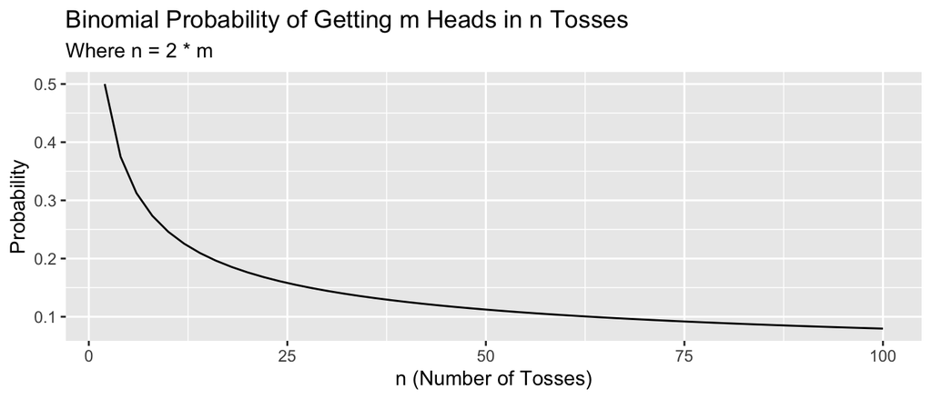

```r
ggplot(df, aes(x = n, y = probability)) +
  geom_line() +
  labs(x = "n (Number of Tosses)", y = "Probability", title = "Binomial Probability of Getting m Heads in n Tosses", subtitle="Where n = 2 * m")
```

2. Suppose you have a random variable $X \sim \text{Binomial}(120, 0.2)$.
- 2a. Calculate and report the mean and standard deviation of the distribution.

```r
n1= 120
p1 = 0.2

mean = n1 * p1
var = n1*p1*(1-p1)
sd = sqrt(var)

mean
```

```
## [1] 24
```

```r
sd
```

```
## [1] 4.38178
```

- 2b. Calculate and report the probability that the random variable is exactly equal to 20, $\mathsf{P}(X = 20)$.

```r
dbinom(20, n1, p1)
```

```
## [1] 0.06293094
```

- 2c. Calculate and report the probability that $X$ equals 20 or more, $\mathsf{P}(X \ge 20)$.

```r
1 - pbinom(19, n1, p1)
```

```
## [1] 0.8482865
```

- 2d. Draw a graph of the binomial distribution with vertical lines at the mean (red and dashed), and 1, 2, and 3 standard deviations above and below the mean (red and dotted).

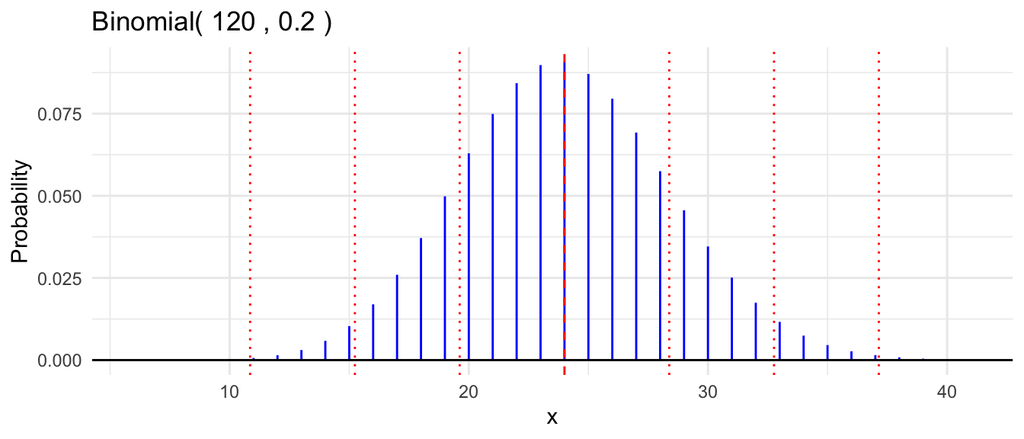

```r
gbinom(n1, p1, scale = TRUE) +
  geom_vline(xintercept = mean, color = "red", linetype = "dashed") +
  geom_vline(xintercept = mean + c(-1,1)*sd,
             color = "red", linetype = "dotted") +
  geom_vline(xintercept = mean + c(-2,2)*sd,
             color = "red", linetype = "dotted") +
  geom_vline(xintercept = mean + c(-3,3)*sd,
             color = "red", linetype = "dotted") +
  theme_minimal()
```

3. What is the probability that $X$ from Problem 2 is within one, two, and three standard deviations of the mean? Round each probability to four decimal places.

```r
# One SD
round(pbinom(mean+sd, n1, p1) - pbinom(mean-sd, n1, p1), 4)
```

```
## [1] 0.696
```

```r
# Two SD
round(pbinom(mean+ 2 * sd, n1, p1) - pbinom(mean- 2 * sd, n1, p1), 4)
```

```
## [1] 0.9486
```

```r
# Three SD
round(pbinom(mean+ 3 * sd, n1, p1) - pbinom(mean- 3 * sd, n1, p1), 4)
```

```
## [1] 0.9979
```

4. The following code makes a graph of the cumulative distribution function for the $\text{Binomial}(7, 0.3)$ distribution, that is $F(x) = \mathsf{P}(X \le x)$. This is the function which is calculated by the base R function `pbinom()`.
- Modify the code to add a horizontal red dotted line at 0.4.

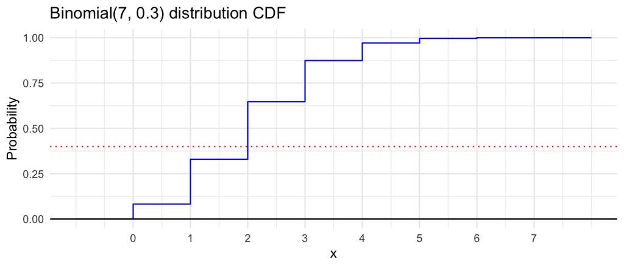

```r
prob4 = tibble(
  x = seq(-1,8,1),
  p = dbinom(x, 7, 0.3),
  cdf = pbinom(x, 7, 0.3))

ggplot(prob4, aes(x = x, y = cdf )) +
  geom_step(color = "blue") +
  geom_hline(yintercept = 0) +
  scale_x_continuous(breaks = 0:7) +
  geom_hline(yintercept = 0.4,
             color = "red", linetype = "dotted") +
  xlab("x") +
  ylab("Probability") +
  ggtitle("Binomial(7, 0.3) distribution CDF") +
  theme_minimal()
```

- Calculate the 0.4 quantile of the $\text{Binomial}(7, 0.3)$

```r
qbinom(0.4, 7, 0.3)
```

```
## [1] 2
```

- Explain how the value of the quantile is related to the red dotted line which you added to the plot.

> The red dotted line at 0.4 on the plot represents the cumulative probability of 0.4. It shows where the cumulative distribution function (CDF) crosses the probability of 0.4 on the y-axis. In this case, it corresponds to x = 2.
- Use the graph to determine the 0.75 quantile of this distribution.

> Using the graph, the 0.75 quantile is x = 3

Then verify your observation with a calculation.

```r
qbinom(0.75, 7, 0.3)
```

```
## [1] 3
```

5. In a large population of likely voters, the proportion of voters who plan to vote for candidate A is $p = 0.52$. In a random sample of 600 likely voters, what is the probability that the proportion of voters who plan to vote for candidate A is less than 50% (the number of such voters is less than 300)?

```r
pbinom(299, 600, 0.52)
```

```
## [1] 0.1535275
```

6. Basketball player 1 makes 80% of their free throws and basketball players 2 makes 70% of their free throws. Assume all of their free throws attempts are independent. If each player takes ten free throws and $X$ is the total number of free throws they make, does $X$ have a binomial distribution? If yes, specify the parameters $n$ and $p$. If not, explain why not.

> $X$ does not have a binomial distribution. The total number of successful free throws $X$ is the sum of the successful free throws from player 1 and player 2. While the number of successful free throws for each player separately does follow a binomial distribution, the distribution of $X$ will be the convolution of two binomial distributions, not a single binomial distribution.
- The two players have different probabilities of success, so we cannot use a single probability $p$ for both.
- Even though the trials are independent within each player’s attempts, the total number of successes $X$ is the sum of two different binomial distributions, one for each player.

> Thus, to find the distribution of $X$, one would need to compute the sum of these two distributions. This sum does not simplify to a single binomial distribution because the probability of success differs between the two players.
7. What is the smallest number of coin tosses $n$ of a fair coin so that the chance of getting 50 or more heads exceeds 90%? (You may need to do some trial and error. Alternatively, think of creating a data frame with a column `n` and a column for the probability and using this to find the answer.)

```r
df2 = tibble(n=seq(100, 150, by=1), p = 0.5, probability = 1 - pbinom(49, n, p))
head(df2 %>% filter(probability > 0.9), 1)
```

```
## # A tibble: 1 × 3
##       n     p probability
##   <dbl> <dbl>       <dbl>
## 1   113   0.5       0.906
```

> Smallest n is 113
8. The random variable $X$ has the $\text{Binomial}(100, 0.2)$ distribution.
- Find an integer $a$ so that $P(X \le a) \ge 0.5$ and $P(X \ge a) \ge 0.5$.
- Show the values of $a$, $P(X \le a)$, and $P(X \ge a)$.

```r
n2 = 100
p2 = 0.2

df3 = tibble(n=100, p = 0.2, a=seq(0,200, by=1), lt = pbinom(a,n,p), mt = 1 - pbinom(a-1,n,p))
df3 %>% filter(lt >= 0.5 & mt >= 0.5)
```

```
## # A tibble: 1 × 5
##       n     p     a    lt    mt
##   <dbl> <dbl> <dbl> <dbl> <dbl>
## 1   100   0.2    20 0.559 0.540
```

- From the dataframe, a = 20, $P(X \le a)$ is 0.559 and $P(X \ge a)$ is 0.540